# Comparing Trail Grade Distributions: Walkthrough

The grade of a trail every 100 m, the same way for every trail: track, points, elevation, smoothing, grade. This notebook runs each step of `scripts/build_grades.py` on one trail (the Tour du Mont Blanc), then shows the results for every trail and how to add one.

Running it needs the Tour du Mont Blanc’s elevation tiles: `make download TRAILS=tmb` (about 100 MB).

## Setup

Settings and trails come from `trails.yaml`.

```python
import sys
from pathlib import Path

import matplotlib.pyplot as plt
import numpy as np
import pandas as pd

sys.path.insert(0, str(Path("../scripts").resolve()))
import build_grades as bg
import plots
from great_tables import GT, loc, style

TEXT_FONT = ["Futura", "Futura PT", "Jost", "Century Gothic", "sans-serif"]
NUM_FONT = "ui-monospace, SFMono-Regular, Menlo, Consolas, monospace"


def table(df, title, decimals=1):
    """Great Tables: sans-serif text, monospace numbers."""
    nums = list(df.select_dtypes("number").columns)
    return (GT(df).tab_header(title=title).fmt_number(columns=nums, decimals=decimals)
            .opt_table_font(font=TEXT_FONT, add=False)
            .tab_style(style=style.text(font=NUM_FONT), locations=loc.body(columns=nums)))

key = "tmb"
trail = bg.CONFIG["trails"][key]
spacing, k = bg.SETTINGS["spacing_m"], bg.SETTINGS["smooth_points"]
trail, spacing, k
```

```
({'name': 'Tour du Mont Blanc',
  'region': 'Europe',
  'long_name': 'Tour du Mont Blanc',
  'osm_relation': 124456,
  'official_km': 165,
  'start': [6.8, 45.89],
  'direction': 'Counter-Clockwise',
  'loop': 'counterclockwise'},
 100,
 3)
```

## 1. Track

The trail’s OpenStreetMap route relation (`data/osm/tmb/`). Only member ways with a main-route role (`keep_roles`) are kept; alternates, spurs, water and ferry legs are dropped. `join_pieces` merges ways that share end points. `orient_pieces` orders the pieces and points each one in the hiking direction: the order with the shortest total gap from `start`, through every piece, to `end`. A loop is then turned to its `loop` direction.

```
742 ways -> 1 piece(s), 166.2 km (published: 165 km)
```

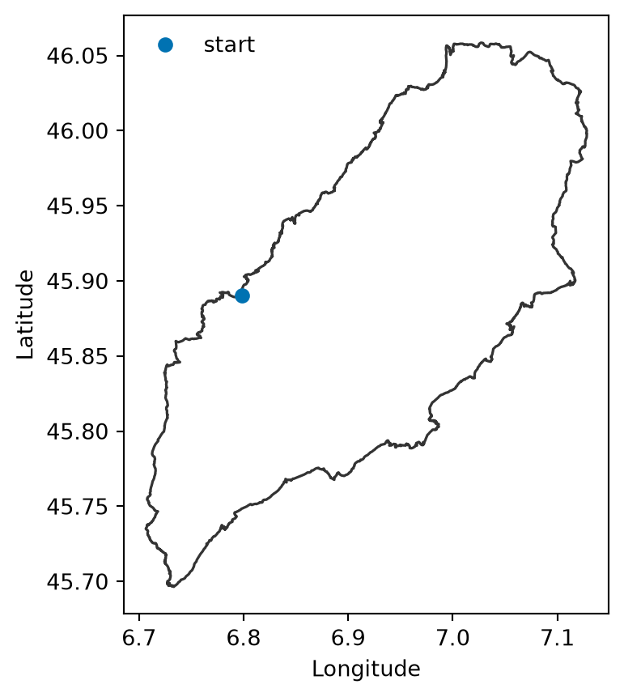

```python
ways = bg.load_ways(key)
pieces = bg.orient_pieces(bg.join_pieces(ways), trail["start"], trail.get("loop"), trail.get("end"))
km = sum(bg.step_m(p[:, 0], p[:, 1]).sum() for p in pieces) / 1000
print(f"{len(ways)} ways -> {len(pieces)} piece(s), {km:.1f} km (published: {trail['official_km']} km)")

fig, ax = plt.subplots(figsize=(5, 5))
for p in pieces:
    ax.plot(p[:, 0], p[:, 1], lw=1.2, color="#333")
ax.plot(*pieces[0][0], "o", color="#0072B2", label="start")
ax.set_aspect(1 / np.cos(np.radians(trail["start"][1])))
ax.set(xlabel="Longitude", ylabel="Latitude")
ax.legend(frameon=False)
plt.show()
```

## 2. Points

New points every `spacing_m` along each piece, distances on the WGS84 ellipsoid (`step_m`: meridian and prime-vertical radii of curvature). The track’s own vertices are not used, so every trail is sampled the same way.

```python
dist, lon, lat = bg.resample(pieces[0], spacing)
print(f"{len(dist)} points, {dist[1] - dist[0]:.0f} m apart")
```

```
1663 points, 100 m apart
```

## 3. Elevation

FABDEM v1-2 at each point, bilinear between the four nearest 30 m cell centers (`fabdem`). Tiles are read from `data/fabdem/`.

```python
raw = bg.fabdem(lon, lat)
print(f"{np.isnan(raw).sum()} points without elevation; range {np.nanmin(raw):.0f} to {np.nanmax(raw):.0f} m")
```

```
0 points without elevation; range 977 to 2533 m
```

## 4. Smooth and 5. Grade

Centered moving average over `smooth_points` points, then rise over run to the next point, in percent. The first and last points of a piece have no average and get no grade.

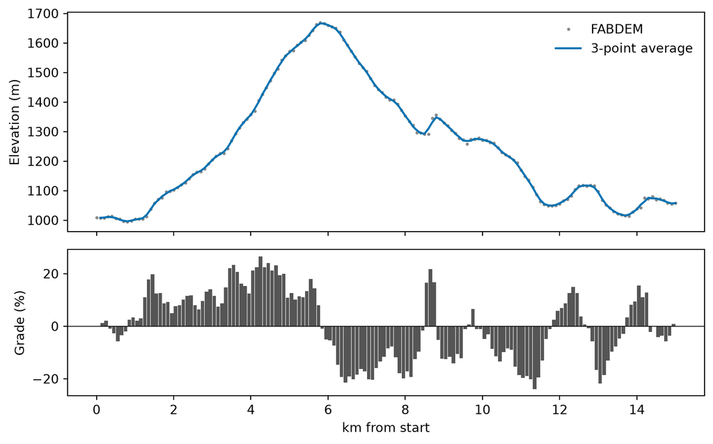

```python
elev = bg.smooth(raw, k)
grade = np.diff(elev) / spacing * 100

n = int((dist <= 15_000).sum())          # first 15 km
fig, (top, bottom) = plt.subplots(2, 1, figsize=(8, 5), sharex=True, height_ratios=[3, 2])
top.plot(dist[:n] / 1000, raw[:n], ".", ms=3, color="#888", label="FABDEM")
top.plot(dist[:n] / 1000, elev[:n], color="#0072B2", lw=1.6, label=f"{k}-point average")
top.set_ylabel("Elevation (m)")
top.legend(frameon=False, loc="upper right")
bottom.bar(dist[:n - 1] / 1000 + spacing / 2000, grade[:n - 1], width=spacing / 1000 * 0.9, color="#555")
bottom.axhline(0, color="black", lw=0.6)
bottom.set(xlabel="km from start", ylabel="Grade (%)")
plt.tight_layout()
plt.show()
```

## The whole trail, at every setting

`build_trail` runs steps 1-5 for every spacing and smoothing in `settings.checks`. It returns the points at the main settings (written to `data/grades/<trail>.csv.gz`) and one summary row per setting (`data/grades/summary.csv`).

```python
points, rows = bg.build_trail(key)
summary = pd.DataFrame(rows)[["spacing_m", "smooth_points", "km_graded", "median_abs_grade", "pct_within_5",
                              "pct_within_10", "pct_over_15", "pct_over_20"]]
table(summary, f"{trail['name']} at every setting").fmt_number(columns=["spacing_m", "smooth_points"], decimals=0)
```

```
Tour du Mont Blanc: 1 pieces, 166 km
```

Tour du Mont Blanc at every setting

| spacing_m | smooth_points | km_graded | median_abs_grade | pct_within_5 | pct_within_10 | pct_over_15 | pct_over_20 |
| --- | --- | --- | --- | --- | --- | --- | --- |
| 50 | 1 | 166.2 | 11.4 | 24.6 | 44.4 | 36.4 | 20.2 |
| 50 | 3 | 166.1 | 10.9 | 25.0 | 46.1 | 33.3 | 17.1 |
| 50 | 5 | 166.0 | 10.8 | 25.4 | 46.5 | 32.2 | 15.1 |
| 100 | 1 | 166.2 | 11.2 | 25.0 | 44.3 | 33.8 | 18.1 |
| 100 | 3 | 166.0 | 10.7 | 25.6 | 47.1 | 32.3 | 14.6 |
| 100 | 5 | 165.8 | 10.3 | 25.8 | 48.4 | 30.6 | 12.7 |
| 200 | 1 | 166.2 | 10.6 | 25.0 | 47.4 | 33.5 | 15.2 |
| 200 | 3 | 165.8 | 10.2 | 25.8 | 49.3 | 29.7 | 12.4 |
| 200 | 5 | 165.4 | 9.8 | 26.2 | 51.0 | 27.7 | 10.2 |

Columns: `pct_within_10` is the % of distance between -10% and 10% grade; `pct_over_15` is steeper than 15%, up or down.

## Every trail

The grades already built, at the main settings (100 m, 3-point average):

```python
s = pd.read_csv("../data/grades/summary.csv")
main = s[(s.spacing_m == spacing) & (s.smooth_points == k)]
cols = ["name", "track_km", "official_km", "pct_within_5", "pct_within_10", "pct_over_10", "pct_over_15", "pct_over_20"]
table(main[cols].sort_values("pct_within_10", ascending=False), "Every trail, 100 m, 3-point average")
```

Every trail, 100 m, 3-point average

| name | track_km | official_km | pct_within_5 | pct_within_10 | pct_over_10 | pct_over_15 | pct_over_20 |
| --- | --- | --- | --- | --- | --- | --- | --- |
| Camino de Santiago | 769.4 | 780.0 | 80.6 | 95.4 | 4.6 | 1.0 | 0.1 |
| Te Araroa | 3,179.6 | 3,000.0 | 73.8 | 89.3 | 10.7 | 5.5 | 2.9 |
| AZT | 1,254.5 | 1,287.0 | 67.6 | 88.8 | 11.2 | 3.8 | 1.0 |
| Tahoe Rim Trail | 270.0 | 266.0 | 46.6 | 85.9 | 14.1 | 0.8 | 0.0 |
| CDT | 4,832.7 | 4,989.0 | 59.5 | 84.7 | 15.3 | 4.2 | 0.8 |
| PCT | 4,219.2 | 4,265.0 | 48.7 | 84.5 | 15.5 | 2.3 | 0.2 |
| Colorado Trail | 768.3 | 782.0 | 45.1 | 81.1 | 18.9 | 5.2 | 0.9 |
| PNT | 1,964.6 | 1,931.0 | 53.3 | 79.7 | 20.3 | 7.2 | 2.4 |
| GDT | 1,131.5 | 1,130.0 | 56.9 | 78.6 | 21.4 | 9.5 | 4.2 |
| Australian Alps | 694.4 | 655.0 | 47.9 | 74.6 | 25.4 | 12.4 | 6.4 |
| AT | 3,394.4 | 3,536.0 | 44.1 | 72.1 | 27.9 | 10.4 | 3.3 |
| JMT | 335.8 | 340.0 | 39.8 | 71.7 | 28.3 | 6.8 | 0.8 |
| Annapurna Circuit | 224.7 | None | 42.9 | 68.1 | 31.9 | 15.5 | 7.6 |
| Senda Pirenaica (GR11) | 835.5 | 840.0 | 33.3 | 60.2 | 39.8 | 21.2 | 10.7 |
| HRP | 757.9 | 800.0 | 28.0 | 52.8 | 47.2 | 28.7 | 15.4 |
| Via Alpina Red | 2,565.0 | None | 29.7 | 52.7 | 47.3 | 28.3 | 15.1 |
| Pyrenean Way (GR10) | 926.9 | 866.0 | 27.8 | 51.4 | 48.6 | 29.6 | 15.1 |
| Via Alpina Green | 394.9 | None | 28.7 | 50.3 | 49.7 | 28.7 | 14.7 |
| Fra li Monti (GR20) | 183.7 | 180.0 | 28.2 | 50.1 | 49.9 | 32.6 | 20.1 |
| Wonderland Trail | 139.2 | 150.0 | 24.7 | 49.8 | 50.2 | 24.3 | 6.8 |
| Tour du Mont Blanc | 166.2 | 165.0 | 25.6 | 47.1 | 52.9 | 32.3 | 14.6 |

The figures from `scripts/plots.py` (`make figures` writes them to `figures/`). Grade density, the first trail as a gray fill:

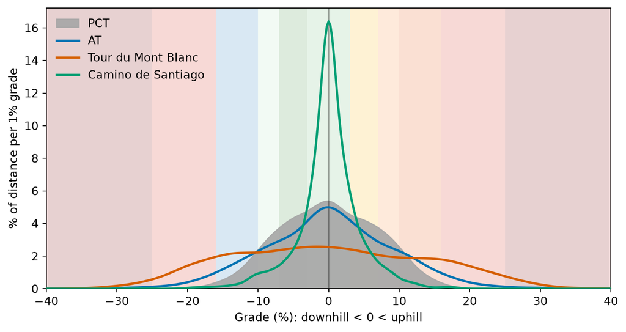

```python
data = plots.load()
fig, ax = plt.subplots(figsize=(9, 4.5))
plots.density(ax, {t: data[t] for t in ["pct", "at", "tmb", "camino_frances"]})
plt.show()
```

Share of distance in each grade zone:

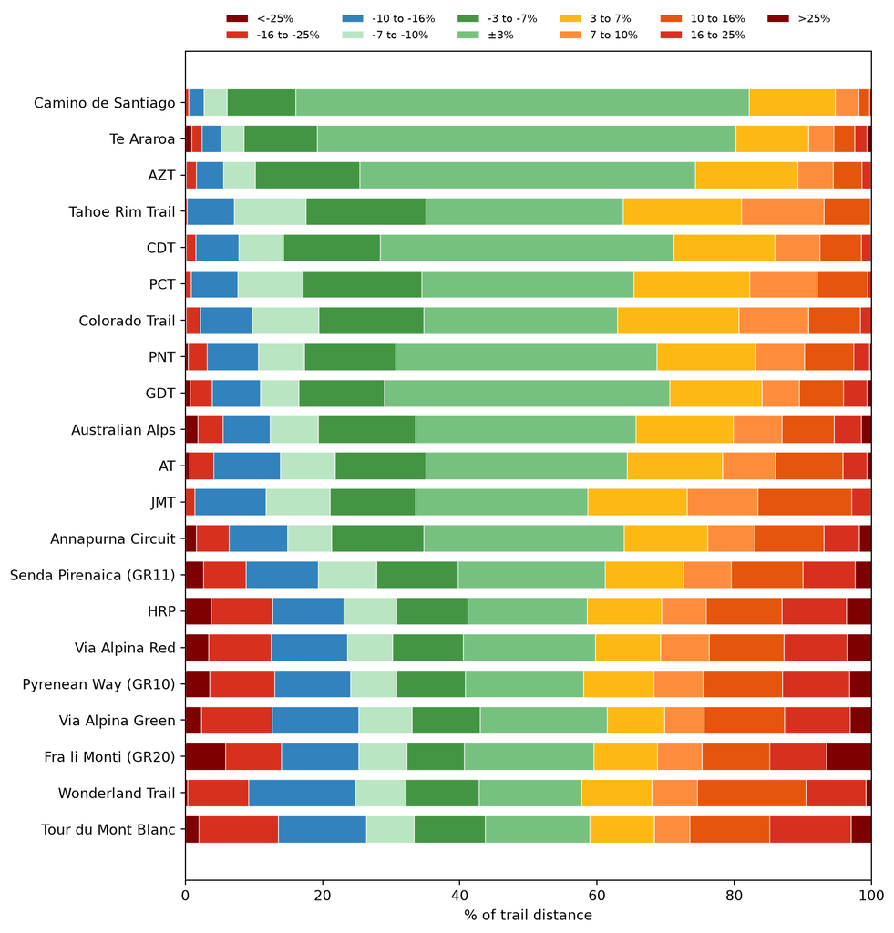

```python
fig, ax = plt.subplots(figsize=(9, 0.45 * len(data) + 1.5))
plots.zone_bars(ax, data)
plt.show()
```

Grade by elevation (darker: more of the trail; black lines: 10th and 90th percentile grade per 500 ft):

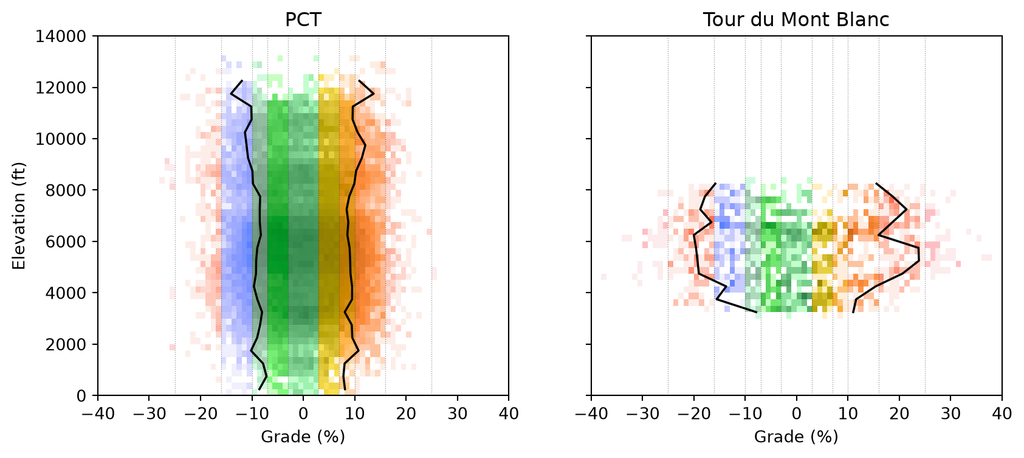

```python
y_max = np.ceil(max(data[t].elev_m.max() for t in ["pct", "tmb"]) * plots.FT / 1000) * 1000
fig, axes = plt.subplots(1, 2, figsize=(10, 4), sharey=True)
for ax, t in zip(axes, ["pct", "tmb"]):
    plots.heatmap(ax, data[t], y_max)
    ax.set(title=plots.name(t), xlabel="Grade (%)")
axes[0].set_ylabel("Elevation (ft)")
plt.show()
```

## Adding a trail

**From OpenStreetMap.** Find the trail’s route relation on [Waymarked Trails](https://hiking.waymarkedtrails.org) or openstreetmap.org, and add it to `trails.yaml`:

```yaml
  my_trail:
    name: My Trail
    region: Americas
    long_name: My Trail
    direction: NoBo
    osm_relation: 1234567          # or a list, for a trail split over several relations
    official_km: 500
    start: [-120.0, 38.0]          # where hikers usually start: sets the sign of grade
    end: [-119.0, 41.0]            # optional, helps order the pieces
```

**From your own track.** Put a GPX or GeoJSON file in `data/tracks/` and use `track_file` instead of `osm_relation`. `start` is optional (default: the file’s first point).

```yaml
  my_hike:
    name: My Hike
    region: Americas
    long_name: My Hike
    direction: SoBo
    track_file: data/tracks/my_hike.gpx
    official_km: null
```

Then:

```bash
make download grades TRAILS=my_trail    # track (OSM only) and elevation tiles, then grades
make figures
```

Check the printed track length against the published one, and the piece count: many pieces or a long track usually means alternates mapped as main route (leave them out with `skip_relations`).